# Process Notebook

Aparajeeta Jha Arvindjit Singh Madhu Shubham Manekar

## Title: Weather Data Analysis using Machine Learning algorithms and Trend Analysis

### Exploratory Data Analysis

### Outlier and Missing values removal:

#### From the first plot, we can infer that for Min.Temperature the Median is around 22 degrees Celsius. On the other hand, for both Max.Temperature and Temp. Dry Bulb the median is around 33 degrees Celsius and 28 degrees Celsius respectively.

```r
library(dplyr)
library(Hmisc)
```

```r
library(ggplot2)
library(readxl)
my_data <- read_excel("FinalModifiedData.xlsx")
my_data <- as.data.frame(my_data)

glimpse(my_data)
```

```
## Rows: 76,706
## Columns: 15
## $ Station.Code      <chr> "Amli", "Amli", "Amli", "Amli", "Amli", "Amli", "...
## $ Year              <dbl> 2000, 2000, 2000, 2000, 2000, 2000, 2000, 2000, 2...
## $ Month             <dbl> 1, 1, 1, 1, 1, 1, 1, 1, 1, 1, 1, 1, 1, 1, 1, 1, 1...
## $ Day               <dbl> 1, 1, 2, 2, 3, 3, 4, 4, 5, 5, 6, 6, 7, 7, 8, 8, 9...
## $ Hour              <chr> "08:30", "17:30", "08:30", "17:30", "08:30", "17:...
## $ Min.Temperature   <dbl> 22.69749, 22.69749, 22.69749, 22.69749, 22.69749,...
## $ Max.Temperature   <dbl> 22.5000, 33.0000, 24.0000, 31.0000, 27.0000, 30.5...
## $ Temp.Dry.Bulb     <dbl> 28.69158, 27.00000, 20.50000, 29.50000, 20.00000,...
## $ Temp.Wet.Bulb     <dbl> 16.5, 23.0, 15.0, 21.5, 17.0, 23.5, 15.5, 23.0, 1...
## $ Relative.Humidity <dbl> 95.0, 70.5, 52.5, 49.5, 73.0, 56.0, 76.0, 49.0, 5...
## $ Inst.Wind.Speed   <dbl> 2.829831, 2.829831, 2.829831, 2.829831, 2.829831,...
## $ Av.Wind.Speed     <dbl> 3.593495, 3.593495, 3.593495, 3.593495, 3.593495,...
## $ Pan.Evaporation   <dbl> 1.5, 2.0, 2.0, 3.0, 1.5, 2.0, 2.0, 2.0, 1.5, 2.0,...
## $ Temp...Pan.Water  <dbl> 27.28991, 27.28991, 27.28991, 27.28991, 27.28991,...
## $ Wind.direction    <chr> "WSW", "WNW", "WNW", "WSW", "WNW", "WSW", "WNW", ...
```

```r
# Removing the Time variables from the dataset
my_data$Station.Code<-NULL
my_data$Hour<-NULL
my_data$Year<-NULL
my_data$Month<-NULL
my_data$Day<-NULL

str(my_data)
```

```
## 'data.frame':    76706 obs. of  10 variables:
##  $ Min.Temperature  : num  22.7 22.7 22.7 22.7 22.7 ...
##  $ Max.Temperature  : num  22.5 33 24 31 27 30.5 28 32 24 33 ...
##  $ Temp.Dry.Bulb    : num  28.7 27 20.5 29.5 20 ...
##  $ Temp.Wet.Bulb    : num  16.5 23 15 21.5 17 23.5 15.5 23 16.5 24.5 ...
##  $ Relative.Humidity: num  95 70.5 52.5 49.5 73 56 76 49 54 74 ...
##  $ Inst.Wind.Speed  : num  2.83 2.83 2.83 2.83 2.83 ...
##  $ Av.Wind.Speed    : num  3.59 3.59 3.59 3.59 3.59 ...
##  $ Pan.Evaporation  : num  1.5 2 2 3 1.5 2 2 2 1.5 2 ...
##  $ Temp...Pan.Water : num  27.3 27.3 27.3 27.3 27.3 ...
##  $ Wind.direction   : chr  "WSW" "WNW" "WNW" "WSW" ...
```

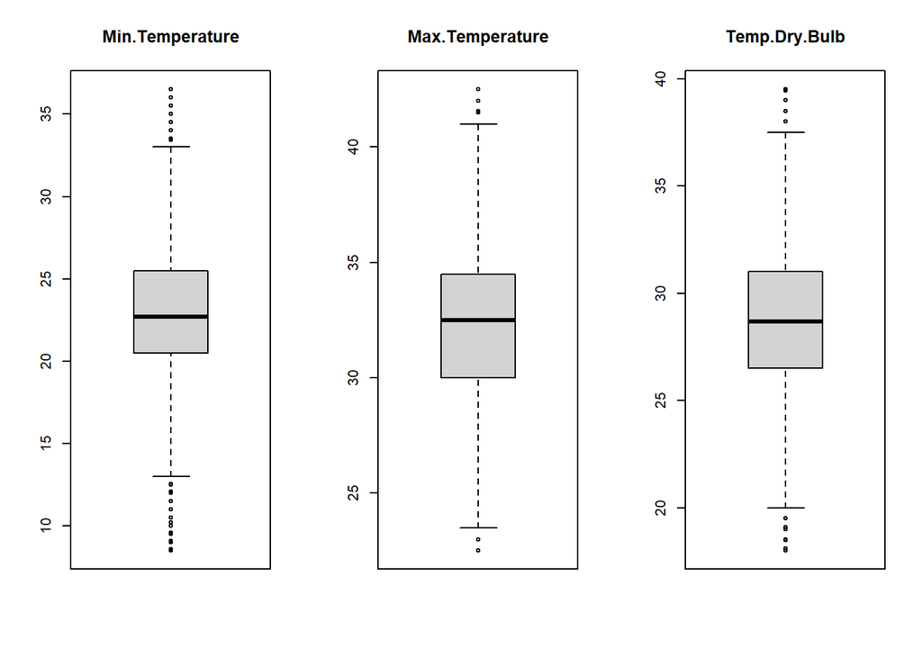

```r
# Create separate boxplots for each attribute
par(mfrow=c(1,3))
for(i in 1:3) {
    boxplot(my_data[,i], main=names(my_data)[i])
}
```

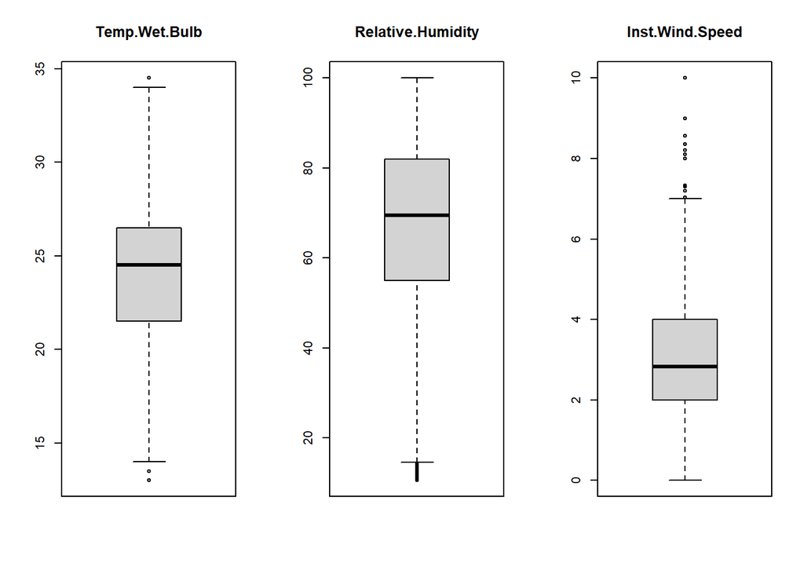

```r
par(mfrow=c(1,3))
for(i in 4:6) {
    boxplot(my_data[,i], main=names(my_data)[i])
}
```

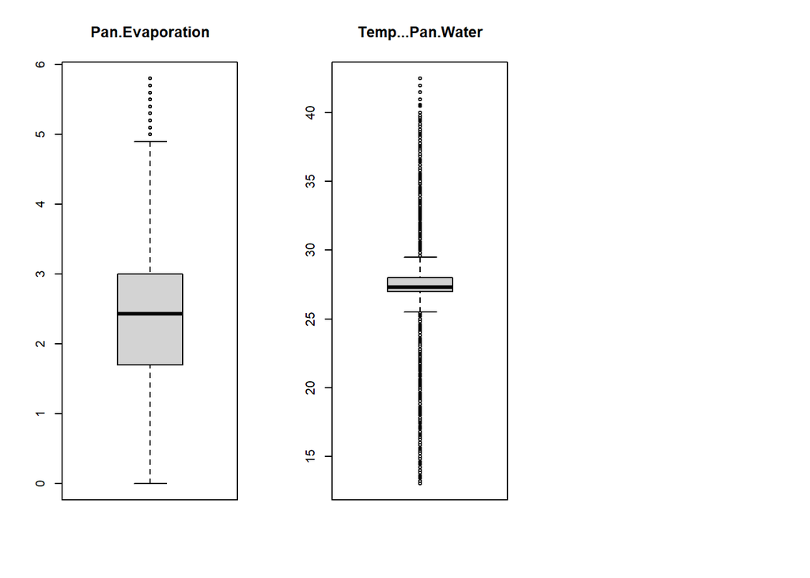

```r
par(mfrow=c(1,3))
for(i in 8:9)
{

  boxplot(my_data[,i], main=names(my_data)[i])
}
```

### Correlation Matrix Inference:

#### From the correlation plot it is evident that there is a positive correlation between:

#### 1. Max. Temperature and Temp.Dry Bulb

#### 2. Temp.Dry bulb and Temp.Wet Bulb

#### 3. Temp.Wet Bulb and Min.Temperature

#### There is a negative correlation between the following variables:

#### 1. Relative Humidity and Max.temp

#### 2. Relative Humidity and Temp.dry bulb

#### 3. Relative Humidity and Pan Evaporation

#### We used IQR method to remove outliers and mean values to impute numerical missing values. To deal with missing categorical values we used KNN method with value of K equals to sqrt(number of distinct values) .

```r
# change categorical values of Wind direction to numerical values for Correlation plot

my_data[my_data=="C"]<-0
my_data[my_data=="E"]<-9
my_data[my_data=="S"]<-18
my_data[my_data=="W"]<-27
my_data[my_data=="N"]<-36
my_data[my_data=="NNE"]<-2
my_data[my_data=="ESE"]<-11
my_data[my_data=="SSW"]<- 20
my_data[my_data=="WNW"]<- 29
my_data[my_data=="V"]<- 99
my_data[my_data=="NE"]<- 5
my_data[my_data=="SE"]<- 14
my_data[my_data=="SW"]<- 23
my_data[my_data=="NW"]<- 32
my_data[my_data=="ENE"]<- 7
my_data[my_data=="SSE"]<- 16
my_data[my_data=="WSW"]<- 25
my_data[my_data=="NNW"]<- 34

my_data$Wind.direction <- as.numeric(as.character(my_data$Wind.direction))

str(my_data)
```

```
## 'data.frame':    76706 obs. of  10 variables:
##  $ Min.Temperature  : num  22.7 22.7 22.7 22.7 22.7 ...
##  $ Max.Temperature  : num  22.5 33 24 31 27 30.5 28 32 24 33 ...
##  $ Temp.Dry.Bulb    : num  28.7 27 20.5 29.5 20 ...
##  $ Temp.Wet.Bulb    : num  16.5 23 15 21.5 17 23.5 15.5 23 16.5 24.5 ...
##  $ Relative.Humidity: num  95 70.5 52.5 49.5 73 56 76 49 54 74 ...
##  $ Inst.Wind.Speed  : num  2.83 2.83 2.83 2.83 2.83 ...
##  $ Av.Wind.Speed    : num  3.59 3.59 3.59 3.59 3.59 ...
##  $ Pan.Evaporation  : num  1.5 2 2 3 1.5 2 2 2 1.5 2 ...
##  $ Temp...Pan.Water : num  27.3 27.3 27.3 27.3 27.3 ...
##  $ Wind.direction   : num  25 29 29 25 29 25 29 25 29 27 ...
```

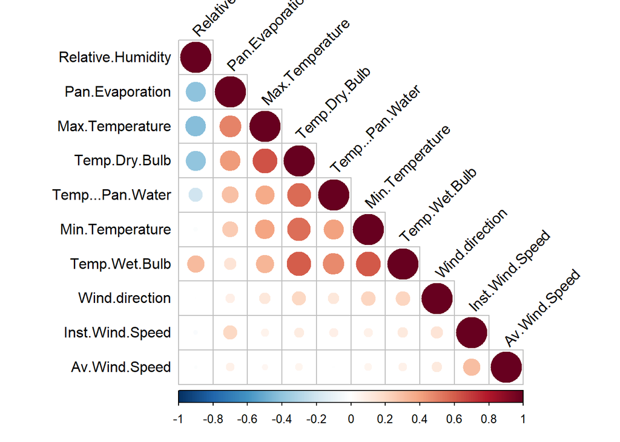

```
## $r
##                   Relative.Humidity Pan.Evaporation Max.Temperature
## Relative.Humidity                 1
## Pan.Evaporation               -0.41               1
## Max.Temperature               -0.43            0.49               1
## Temp.Dry.Bulb                  -0.4            0.42            0.63
## Temp...Pan.Water               -0.2            0.29            0.37
## Min.Temperature               -0.02            0.25            0.39
## Temp.Wet.Bulb                  0.31            0.15            0.33
## Wind.direction              0.00074           0.089            0.13
## Inst.Wind.Speed              -0.024             0.2           0.062
## Av.Wind.Speed                -0.012           0.072            0.04
##                   Temp.Dry.Bulb Temp...Pan.Water Min.Temperature Temp.Wet.Bulb
## Relative.Humidity
## Pan.Evaporation
## Max.Temperature
## Temp.Dry.Bulb                 1
## Temp...Pan.Water           0.57                1
## Min.Temperature            0.55              0.4               1
## Temp.Wet.Bulb               0.6             0.47            0.61             1
## Wind.direction              0.2             0.13            0.21          0.21
## Inst.Wind.Speed             0.1            0.081           0.079          0.11
## Av.Wind.Speed             0.056           -0.006           0.054         0.074
##                   Wind.direction Inst.Wind.Speed Av.Wind.Speed
## Relative.Humidity
## Pan.Evaporation
## Max.Temperature
## Temp.Dry.Bulb
## Temp...Pan.Water
## Min.Temperature
## Temp.Wet.Bulb
## Wind.direction                 1
## Inst.Wind.Speed             0.15               1
## Av.Wind.Speed               0.11             0.3             1
##
## $p
##                   Relative.Humidity Pan.Evaporation Max.Temperature
## Relative.Humidity                 0
## Pan.Evaporation                   0               0
## Max.Temperature                   0               0               0
```

[output cut: 51 more lines]

```
## Inst.Wind.Speed
## Av.Wind.Speed
##                   Wind.direction Inst.Wind.Speed Av.Wind.Speed
## Relative.Humidity
## Pan.Evaporation
## Max.Temperature
## Temp.Dry.Bulb
## Temp...Pan.Water
## Min.Temperature
## Temp.Wet.Bulb
## Wind.direction    1
## Inst.Wind.Speed                  1
## Av.Wind.Speed                                    1
## attr(,"legend")
## [1] 0 ' ' 0.3 '.' 0.6 ',' 0.8 '+' 0.9 '*' 0.95 'B' 1
```

```r
source("http://www.sthda.com/upload/rquery_cormat.r")
require("corrplot")
rquery.cormat(my_data)
```

### Trend Analysis:

#### For both the methodologies, Mann Kendall Method and Sen’s Slope Method, following hypotheses are used.

#### Null Hypothesis H0: The hypothesis being tested. A hypothesis for no change or no difference or no trend.

#### Alternate Hypothesis H1: Some departure from H0 that might be expected. The departure that one expects to see which means the trend exists.

#### Mann-Kendall Method:

#### The M - K test is a statistical nonparametric test widely used for trend analysis in climatological and hydrological time series data. The test was suggested by Mann (1945) and has been extensively used with environmental time series. There are two advantages to use this test. First, it is a nonparametric test and does not require the data to be normally distributed. Second, the test has low sensitivity to abrupt breaks due to inhomogeneous time series. According to this test, the null hypothesis H0 assumes that there is no trend (the data is independent and randomly ordered). This is tested against the alternative hypothesis H1, which assumes that there is trend.

This test has been calculated using Kendall package in R.

#### Sen’s Slope Method:

#### It is distribution free and not affected by seasonal fluctuations. This technique involves in arranging the collected data in the rank wise and scatter plotting and then calculating the median of those data. Based on that median of the data type of trend is decided. This test computes both the slope (i.e. linear rate of change) and confidence levels according to Sen’s method.

This test has been calculated using Trend package in R.

#### Station wise Analysis:

#### In station wise analysis, the values of maximum temperature have been grouped together along the Year and Month and mean value is summarized for each of the seven stations. The graphs show the decomposition of maximum temperature across the years for the data, seasonal, trend and remainder for all the stations. The example graph for Amli shows the data distributions which are too random to detect the trends. Hence the statistical methods.

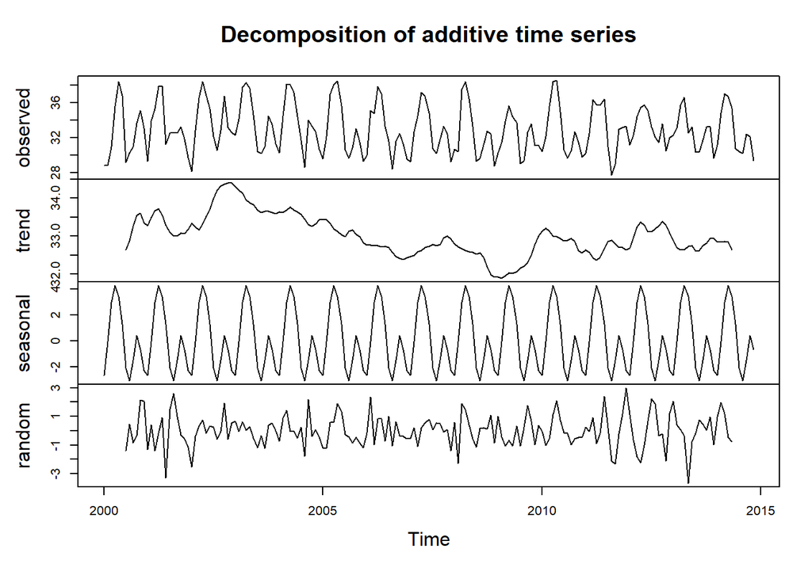

#### The results of our Mann-Kendall analysis are as follows:

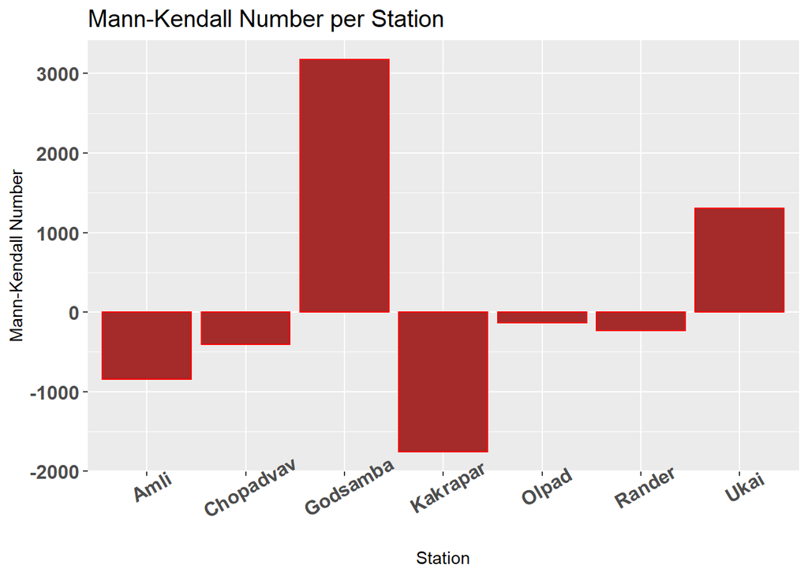

#### The results of our Sen’s Slope Analysis are as follows:

```
## [1] "Amli"      "Chopadvav" "Godsamba"  "Kakrapar"  "Olpad"     "Rander"
## [7] "Ukai"
```

```
## [1] "-0.012823129  0.003736017" "-0.010512591  0.006200204"
## [3] "0.004200269 0.016581962"   "-3.6253639999999997E-2"
## [5] "-0.007040323  0.005842660" "-0.006687601  0.005299167"
## [7] "-0.001241492  0.009260753"
```

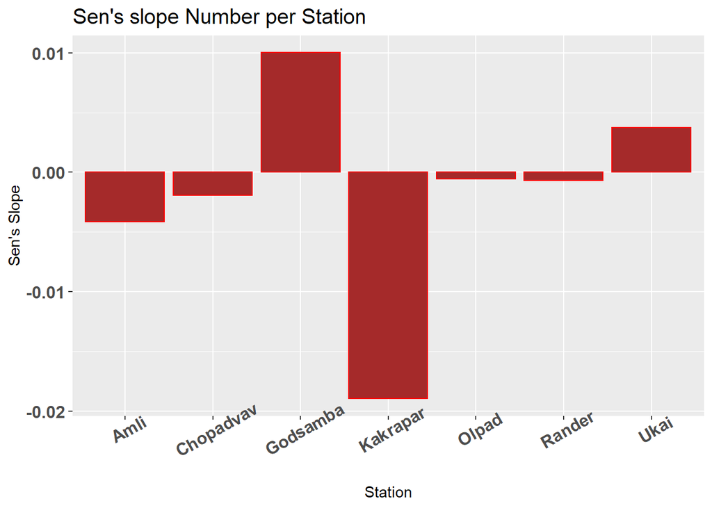

#### The values of Sen’s slope and their respective 95% confidence Intervals are shown in the above tab. The 95% Confidence Interval reflects the range of sen’s slope values for which the trend exists i.e. the alternate hypothesis is considered.

#### Month wise Analysis:

#### In month wise analysis, the values of maximum temperature have been grouped together along the Month and Stations and mean value is summarized for each month. The figure shows the Mean maximum temperature for January for the entire data from 1999 to 2014 for above mentioned stations in that order. Black line represents the plot of the data and blue line represents the fitted line for the data.

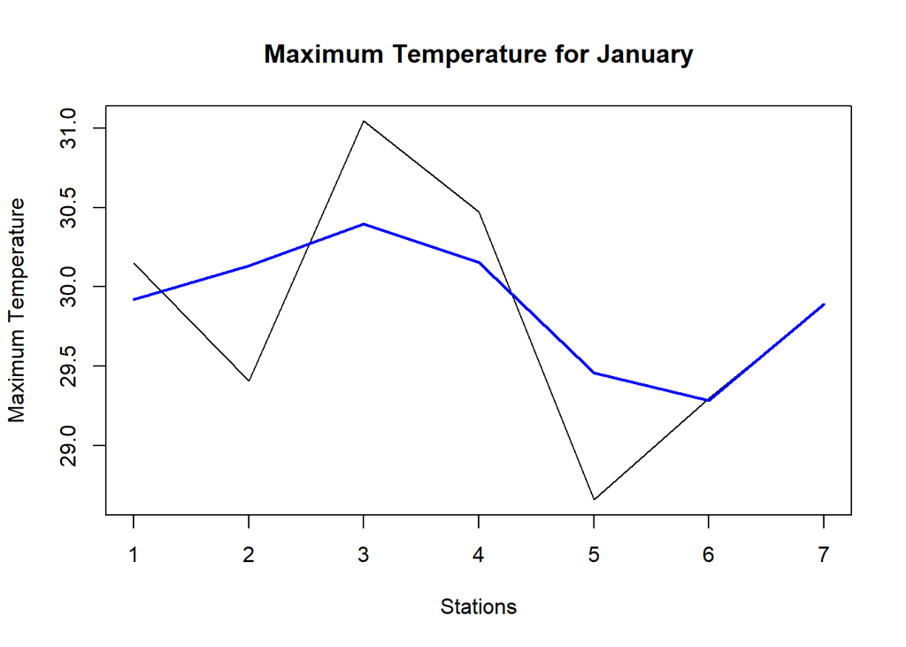

### Month wise results for Mann Kendall Method are shown below:

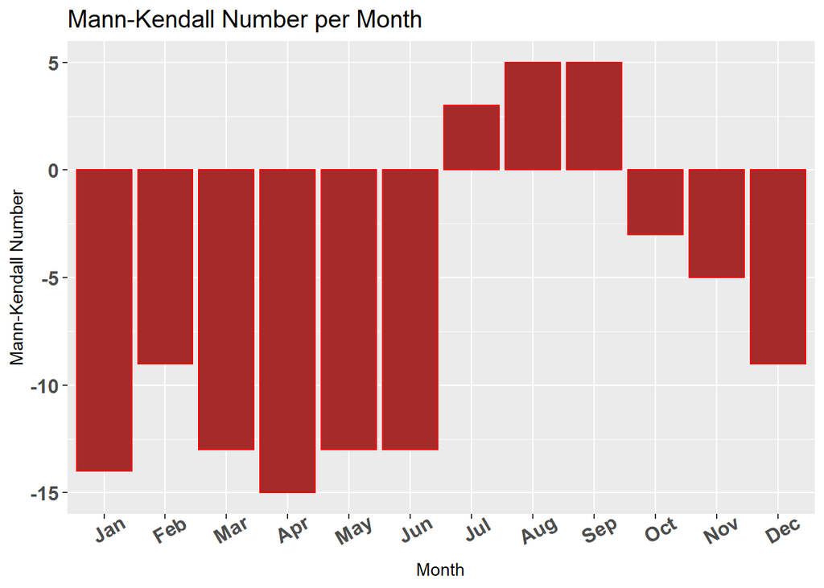

#### As per the study and the graphs shown in the Figure, January, March, April, May and June have a decreasing trend and July, August and September have a little significant increasing trend over the years.

#### Month wise results for Sen’s Slope are shown below:

```
##  [1] "Jan" "Feb" "Mar" "Apr" "May" "Jun" "Jul" "Aug" "Sep" "Oct" "Nov" "Dec"
```

```
##  [1] "-0.5882619  0.5904220"   "-0.8554830  0.6020128"
##  [3] "-0.8656059  0.1557382"   "-0.80726812000000003"
##  [5] "-0.98924533  0.09064614" "-0.60561971  0.04704315"
##  [7] "-0.1940629  0.1095391"   "-0.1140009  0.3881777"
##  [9] "-0.2350412  0.3403352"   "-0.4769571  0.2893008"
## [11] "-0.2959403  0.1610538"   "-0.3499907  0.1463105"
```

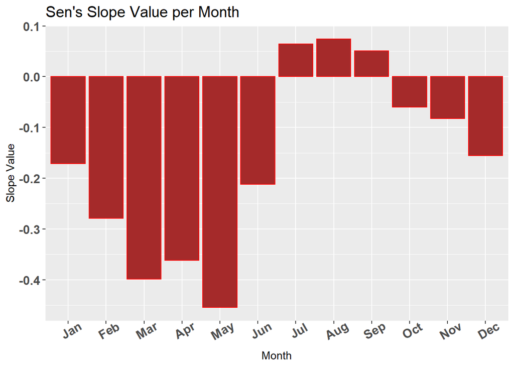

### Predictive Analysis:

#### Linear Regression:

#### For predicting values of Max. temperature, we have used Linnear regression as one of the ML algorithms.

```r
library("readxl")
Result <- read_excel("Linear_Regression.xlsx")
```

```
## * `` -> ...1
```

```r
print(Result)
```

[output not shown]

### Links:

Dataset: https://github.com/arvindjit03/WeatherDataAnalysisinR/blob/master/Weather_Data.xlsx?raw=true  
Project Repository: https://github.com/arvindjit03/WeatherDataAnalysisinR/  
Website: https://sites.google.com/view/dswrweather/home  
Screen Cast: https://www.youtube.com/watch?v=jZp-fKNxvwc

### References:

#### 1. Arora, M., Goel, N.K. and Singh, P. (2005) Evaluation of temperature trends over India. Hydrological Sciences Journal, 50, 8193.

#### 2. Arpita Panda, Netrananda Sahu (2019) Trend analysis of rainfall and temperature pattern in Kalahandi, Bolangir and Koraput districts of Odisha, India, Atmospheric Science Letters.

#### 3. Robert M. Hirsch, James R. Slack (1984) A non parametric trend test for seasonal data with serial dependence. Water Resources Research, Vol. 20, Issue 6, 727-732

#### 4. Praveen Rathod (2014), A comparative study of methods used for rainfall trend analysis. Seminar 2014, M.Tech WRE.